# classwork

```r
glimpse(governors)
```

```
## Rows: 1,092
## Columns: 14
## $ state        <chr> "Alabama", "Alabama", "Alabama", "Alabama", "Alabama", "A…
## $ year         <int> 1946, 1946, 1950, 1954, 1954, 1958, 1962, 1966, 1966, 197…
## $ first_name   <chr> "James", "Lyman", "Gordon", "Tom", "James", "William", "G…
## $ last_name    <chr> "Folsom", "Ward", "Persons", "Abernethy", "Folsom", "Long…
## $ party        <chr> "Democrat", "Republican", "Democrat", "Republican", "Demo…
## $ sex          <chr> "Male", "Male", "Male", "Male", "Male", "Male", "Male", "…
## $ died         <date> 1987-11-21, 1948-12-17, 1965-05-29, 1968-03-07, 1987-11-…
## $ status       <chr> "Challenger", "Challenger", "Challenger", "Challenger", "…
## $ win_margin   <dbl> 77.334394, -77.334394, 82.206564, -46.748166, 46.748166, …
## $ region       <chr> "South", "South", "South", "South", "South", "South", "So…
## $ population   <dbl> 2906000, 2906000, 3058000, 3014000, 3014000, 3163000, 332…
## $ election_age <dbl> 38.07255, 78.54894, 48.74743, 46.54620, 46.07255, 33.2703…
## $ death_age    <dbl> 79.11567, 80.66530, 63.31006, 59.88227, 79.11567, 87.8193…
## $ lived_after  <dbl> 41.043121, 2.116359, 14.562628, 13.336071, 33.043121, 54.…
```

```r
view(governors)
```

# What is the influence of age and gender on the expected longevity of political candidates?

Wisdom:

- Based in US -> governors, but we want to understand all types of political candidates
- years of election from 1945-2011, if we are making predictions about the future and this data set is limited to nearly 10 years ago
- people are living longer
- not as many data points for women (increase of women’s participation in recent decades)
- includes election age, death age, and lived after

population- question doesn’t specify, but we want the population to be American governors validity representativeness- past governors (about the rows)

##justice- predictive or causal model - there’s no causation without manipulation -> predictive model, we can’t manipulate or randomly assign age or gender

$lived\_after_{i} = \beta_0 + \beta_1 election\_age_{i} + \beta_2 sex_{i} +\epsilon_{i}$

we have to choose a specific sex for the equation $lived\_after_{i} = \beta_0 + \beta_2 male_{i} + \beta_1 election\_age_{i} +\epsilon_{i}$

**data generating mechanism- assumptions that we are making

```r
fit_1 <-        stan_glm(formula = lived_after ~ sex + election_age,
                     data = governors,
                     refresh =0,
                     seed = 12)

print(fit_1)
```

```
## stan_glm
##  family:       gaussian [identity]
##  formula:      lived_after ~ sex + election_age
##  observations: 1092
##  predictors:   3
## ------
##              Median MAD_SD
## (Intercept)  66.0    3.2
## sexMale       6.1    2.4
## election_age -0.8    0.0
##
## Auxiliary parameter(s):
##       Median MAD_SD
## sigma 11.1    0.2
##
## ------
## * For help interpreting the printed output see ?print.stanreg
## * For info on the priors used see ?prior_summary.stanreg
```

intercept = unknown female base age 60-72 sexmale = 6.1 years higher election_age = when comparing two candidates who differ by one year in election age then the older one will live .8 years less. slope = -.8

```r
fit_2 <-        stan_glm(formula = lived_after ~ sex + election_age + sex*election_age,
                     data = governors,
                     refresh = 0,
                     seed = 12)
```

$lived\_after_{i} = \beta_0 + \beta_1 election\_age_{i} + \beta_2 male_{i} + \beta_3 male_{i}*election\_age_{i} + \epsilon_{i}$

```r
print(fit_2)
```

```
## stan_glm
##  family:       gaussian [identity]
##  formula:      lived_after ~ sex + election_age + sex * election_age
##  observations: 1092
##  predictors:   4
## ------
##                      Median MAD_SD
## (Intercept)          19.6   22.9
## sexMale              53.2   23.0
## election_age         -0.1    0.4
## sexMale:election_age -0.8    0.4
##
## Auxiliary parameter(s):
##       Median MAD_SD
## sigma 11.1    0.2
##
## ------
## * For help interpreting the printed output see ?print.stanreg
## * For info on the priors used see ?prior_summary.stanreg
```

intercept: average lived_after for females

sexMale: when added to the intercept, it provides the average number of years lived for males candidates on the day of election for people who are aged 0 (not actually useful)

sexMale:election_age - (added to election age / Beta2 + Beta3) -.9 = slope, if we have two men the older one will live for .9 years less

for women the relationship between lived posted election and age at time of election is flat (everyone lives about the same amount of time)

For men the relationship is stronger, the older you are the fewer years you live post_election

```r
#Using fit_2, let’s calculate the expected lived_after for male and female
#candidates with election_age’s equal to 30, 45 and 60.

newobs <- tibble( sex = rep(c("Male", "Female"), 3), election_age = rep(c(30, 45, 60), 2),
                  names = paste(sex, election_age, sep = "_"))

 pe <- posterior_epred(object = fit_2,
                      newdata = newobs) %>%
                      as_tibble() %>%

   #use set names to take heading names from newobs
                      set_names( newobs$names) %>%
   pivot_longer(names_to = "group",
                           values_to = "years_lived",
                           cols = c("Male_30": "Female_60")) %>%
   separate(group, into = c("sex", "group"), "_")


#pivot_longer(cols = Male_30 : Female_60,
            #   names_to = c("age", "sex"),
             #  values_to = "lived_after",
#names_sep = "_")

#There is an unknown ture reality out there regarding the average amount of years men would live on averge after election. Here we have a posterior distribution for the average amount of year's lived after election for the age and sex specified. Each column includes 4,000 draws of possible average years that a person could have lived based on our model.
```

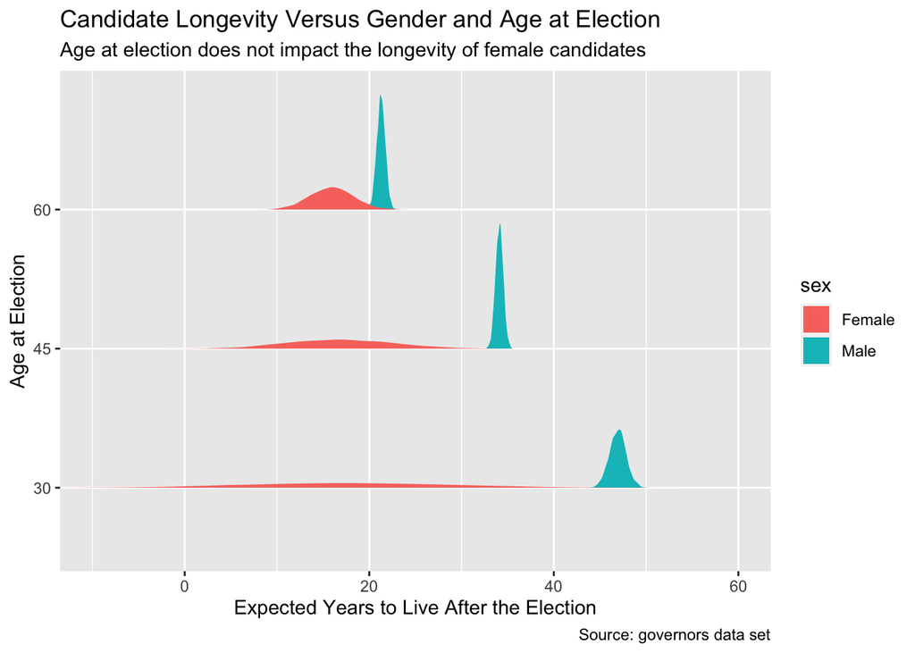

```r
pe %>%


                ggplot(aes(x = years_lived, y = group)) +
                stat_slab(aes(fill = sex)) +
                labs(title = "Candidate Longevity Versus Gender and Age at Election",
 #I had to fix this line so that the second part was in line with the first line
 #of the subtitle
                     subtitle = "Age at election does not impact the longevity of female candidates",
                     caption = "Source: governors data set",
                     x = "Expected Years to Live After the Election",
                     y = "Age at Election") +
                scale_x_continuous(labels = scales::number_format(accuracy = 1)) +
                coord_cartesian(xlim = c(-10, 60))
```

Age at election impacts men and not women. Because of the spread of the female posteriors we can be less certain about any conclusions regarding the expected years to live after election. Since there were more men in the data set, the posteriors for males are more conclusive and condensed than those of women